GeoStat Lab · M10 · Previsione e progetto statistico

M10_N07 · Futura

# Aprire il test e confrontare gli errori

5 blocchi R eseguiti1 grafico0 errori · 0 avvisiOffline · MathML

Codice, output e figure dello stesso svolgimento. Ogni notebook riparte dai dati locali ed è autonomo rispetto agli altri.

# La domanda

Come si confrontano i metodi sul periodo escluso?

## Obiettivi

- Usare gli stessi 36 bersagli per tutti i metodi.
- Calcolare MAE, RMSE e bias con segno esplicito.
- Distinguere valutazione finale e nuova selezione.

**Prima di iniziare.** Sono richiesti vettori, tabelle e funzioni R di base. I blocchi vanno eseguiti in ordine. Il notebook è autonomo rispetto agli altri.

**Dati e unità.** CO₂ storica: 204 mesi da gennaio 1985 a dicembre 2001, concentrazione in ppm. Le medie derivano dalle osservazioni settimanali attribuite al mese della data, secondo la convenzione del corso. Sono dati storici, distinti da una serie mensile ufficiale e da una misura attuale. Il protocollo usa 168 mesi per l’adattamento (1985–1998) e 36 per il test (1999–2001).

## Preparazione

Aprire il progetto autonomo di Futura o quello generale del corso. I calcoli usano R base e stats. Gli output del notebook vanno in `Risultati/M10_N07/`; i CSV originali restano invariati.

Codice R · preparazione

```r
# Trova la cartella M10 dal progetto autonomo o dal progetto generale.
.gs_cerca <- normalizePath(getwd(),winslash="/",mustWork=TRUE)
repeat {
  .gs_candidati <- c(.gs_cerca,
    file.path(.gs_cerca,"M10_Futura"),
    file.path(.gs_cerca,"03_Notebook_svolti","M10_Futura"),
    file.path(.gs_cerca,"M10","03_Notebook_svolti","M10_Futura"))
  .gs_ok <- file.exists(file.path(.gs_candidati,"M10_N01.Rmd")) &
    file.exists(file.path(.gs_candidati,"R","funzioni_notebook.R"))
  if(any(.gs_ok)) { .gs_modulo <- .gs_candidati[which(.gs_ok)[1L]]; break }
  .gs_padre <- dirname(.gs_cerca)
  if(.gs_padre==.gs_cerca) stop("Aprire il progetto M10_Futura o quello generale dei notebook.")
  .gs_cerca <- .gs_padre
}
source(file.path(.gs_modulo,"R","funzioni_notebook.R"),local=TRUE)
.gs_funzioni <- .gs_prepara_notebook(.gs_modulo,"M10_N07")
carica_dati <- .gs_funzioni$carica_dati
percorso_risultati <- .gs_funzioni$percorso_risultati
options(width=88,digits=6)
if(requireNamespace("knitr",quietly=TRUE)) {
  knitr::opts_chunk$set(echo=TRUE,error=FALSE,warning=TRUE,message=TRUE,
    fig.width=8,fig.height=5,dpi=150,fig.align="center")
}
set.seed(10007)
```

## 1. Le previsioni precedono il confronto

I metodi sono quelli del protocollo già dichiarato. Il test viene usato qui per quantificare la prestazione.

Codice R · passo_01

```r
c2 <- prepara_co2(carica_dati("co2_1985_2001.csv"))
train <- c2$train; test <- c2$test; h <- c2$h
fit <- stima_sarima(train)
 pred <- baseline_co2(train,h)[c("Ultimo","Stagionale","Deriva")]
 pred$SARIMA <- as.numeric(predict(fit,n.ahead=h)$pred)
 stopifnot(all(vapply(pred,length,integer(1))==length(test)))
 data.frame(h=1:3,osservato=as.numeric(test)[1:3],
            previsto_SARIMA=pred$SARIMA[1:3])
```

Output eseguito

```
  h osservato previsto_SARIMA
1 1    368.12         368.026
2 2    368.85         368.836
3 3    369.60         369.807
```

**Lettura del risultato.** Tutti i metodi partono dal dicembre 1998. Nessuno aggiorna la previsione usando i valori del test nei mesi successivi.

## 2. Tre metriche descrivono aspetti diversi

Definiamo $e_h=y_{T+h}-\hat y_{T+h}$, $MAE=\operatorname{media}|e_h|$ e $RMSE=\sqrt{\operatorname{media}(e_h^2)}$. Un bias positivo indica sottostima media.

Codice R · passo_02

```r
risultati <- as.data.frame(do.call(rbind,lapply(pred,function(p) metriche(test,p))))
risultati$modello <- rownames(risultati)
rownames(risultati) <- NULL
risultati <- risultati[,c("modello","MAE","RMSE","bias_osservato_meno_previsto")]
risultati
write.csv(risultati,percorso_risultati("metriche_test.csv"),row.names=FALSE)
```

Output eseguito

```
     modello      MAE    RMSE bias_osservato_meno_previsto
1     Ultimo 2.839306 3.33641                     2.554861
2 Stagionale 2.865694 3.10883                     2.865694
3     Deriva 1.884206 2.14827                     0.117735
4     SARIMA 0.974469 1.06219                    -0.968499
```

**Lettura del risultato.** MAE e RMSE restano in ppm. RMSE pesa maggiormente gli errori ampi, mentre il bias può nascondere compensazioni fra segni.

## 3. Il calendario localizza gli errori

La prestazione riassuntiva va accompagnata dalla successione degli scarti per riconoscere errori persistenti.

Codice R · passo_03

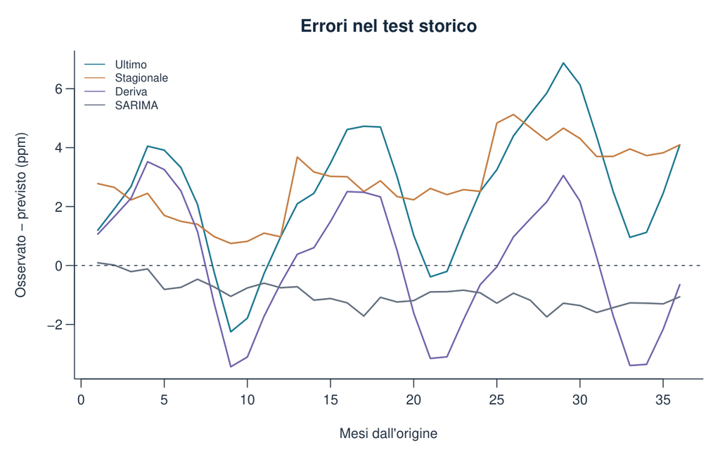

Figura 1 · Output del blocco `passo_03`. PDF vettoriale.

```r
errori <- sapply(pred,function(p) as.numeric(test)-p)
stile_grafico()
matplot(1:h,errori,type="l",lty=1,col=palette_geo,lwd=1.7,
  xlab="Mesi dall'origine",ylab="Osservato - previsto (ppm)",main="Errori nel test storico")
abline(h=0,lty=2)
legend("topleft",names(pred),col=palette_geo,lty=1,bty="n",cex=.8)
```

**Lettura del risultato.** Le curve rendono visibili scostamenti sistematici e stagionalità residua. Un solo holdout resta una verifica limitata di trasferibilità.

## Variante svolta

**MAE e RMSE ordinano allo stesso modo?.** Ordinare le tabelle secondo due perdite e confrontare la graduatoria.

Codice R · variante

```r
data.frame(posizione=seq_len(nrow(risultati)),
  ordine_MAE=risultati$modello[order(risultati$MAE)],
  ordine_RMSE=risultati$modello[order(risultati$RMSE)])
```

Output eseguito

```
  posizione ordine_MAE ordine_RMSE
1         1     SARIMA      SARIMA
2         2     Deriva      Deriva
3         3     Ultimo  Stagionale
4         4 Stagionale      Ultimo
```

Una graduatoria diversa può riflettere il peso degli errori grandi. La metrica va scelta in rapporto alla domanda prima di usare il test per decidere.

## Errore da riconoscere

Dopo aver visto la graduatoria del test, cambiare ordini finché il modello supera i riferimenti e riportare lo stesso test come indipendente.

## Risposta alla domanda

Il confronto usa gli stessi bersagli, le stesse unità e un’origine comune. La tabella finale quantifica ciò che accade in questo segmento storico, con il protocollo fissato.

## Riferimento nel corso

Questo svolgimento sviluppa il laboratorio `M10_N07` di [GeoStat Lab M10](https://marzione00.github.io/Lab_Geo/#indice). Il [codice originale del laboratorio](https://github.com/marzione00/Lab_Geo/blob/649f7cc577b96bd1044d81e78a2f530813e4f96b/materiali/laboratori/M10/M10_N07.R) è conservato anche in `R/Originali_corso`. Gli ampliamenti e le varianti sono identificati nella mappa allegata.

Documentazione dei metodi: [R stats, arima](https://stat.ethz.ch/R-manual/R-devel/library/stats/html/arima.html), [predict.Arima](https://stat.ethz.ch/R-manual/R-devel/library/stats/html/predict.arima.html), [Box.test](https://stat.ethz.ch/R-manual/R-devel/library/stats/html/box.test.html) e [p.adjust](https://stat.ethz.ch/R-manual/R-devel/library/stats/html/p.adjust.html).